# Analyse gamma’s

Richel Bilderbeek

2016-05-24

Loading this package

```r
library(Cer2016)
```

## Collecting gamma’s from one or more phylogenies

```r
phylogenies <- c(ape::rcoal(10), ape::rcoal(20))
df <- collect_gamma_statistics(phylogenies)
knitr::kable(df)
```

| id | gamma_stat |
| --- | --- |
| 1 | 3.126720 |
| 2 | 3.654822 |

## Collecting gamma’s from the species trees

```r
filename <- find_path("toy_example_3.RDa")
df <- collect_species_tree_gammas(filename)
testit::assert(names(df) == c("species_tree", "gamma_stat"))
testit::assert(nrow(df) == 2)
knitr::kable(df)
```

| species_tree | gamma_stat |
| --- | --- |
| 1 | -0.8567307 |
| 2 | -0.8567307 |

## Collecting gamma’s from the posterior

```r
filename <- find_path("toy_example_3.RDa")
df <- collect_posterior_gammas(filename)
testit::assert(names(df) ==
  c("species_tree", "alignment", "beast_run", "gamma_stat")
)
testit::assert(nrow(df) == 80)
knitr::kable(head(df))
```

| species_tree | alignment | beast_run | gamma_stat |
| --- | --- | --- | --- |
| 1 | 1 | 1 | -0.7760589 |
| 1 | 1 | 1 | -0.9833685 |
| 1 | 1 | 1 | -1.1986747 |
| 1 | 1 | 1 | -1.3442141 |
| 1 | 1 | 1 | -0.8632066 |
| 1 | 1 | 1 | -0.9591119 |

## Collecting gamma’s from a file

```r
filename <- find_path("toy_example_3.RDa")
df <- collect_file_gammas(filename)
testit::assert(names(df) == c("species_tree_gammas", "posterior_gammas"))
testit::assert(
  names(df$species_tree_gammas) == c("species_tree", "gamma_stat")
)
testit::assert(names(df$posterior_gammas) ==
  c("species_tree", "alignment", "beast_run", "gamma_stat")
)
testit::assert(nrow(df$species_tree_gammas) == 2)
testit::assert(nrow(df$posterior_gammas) == 80)
```

## Collecting gamma’s from some files

```r
folder <- "/home/p230198/Peregrine"
all_parameter_filenames <- paste(folder, list.files(folder, pattern = "\\.RDa"), sep = "/")
df <- collect_files_gammas(head(all_parameter_filenames), verbose = TRUE)
```

[output not shown]

[output not shown]

```r
testit::assert(names(df)
  == c("species_tree_gamma_stats", "posterior_gamma_stats")
)
knitr::kable(df$species_tree_gamma_stats)
```

| filenames | species_tree | gamma_stat |
| --- | --- | --- |
| article_0_0_0_0_0.RDa | NA | NA |
| article_0_0_0_0_1.RDa | NA | NA |
| article_0_0_0_0_2.RDa | 1 | 0.1567163 |
| article_0_0_0_0_2.RDa | 2 | 0.1567163 |
| article_0_0_0_1_0.RDa | NA | NA |
| article_0_0_0_1_1.RDa | NA | NA |
| article_0_0_0_1_2.RDa | NA | NA |

```r
knitr::kable(head(df$posterior_gamma_stats))
```

| filenames | species_tree | alignment | beast_run | gamma_stat |
| --- | --- | --- | --- | --- |
| article_0_0_0_0_0.RDa | NA | NA | NA | NA |
| article_0_0_0_0_1.RDa | NA | NA | NA | NA |
| article_0_0_0_0_2.RDa | 1 | 1 | 1 | 0.1962860 |
| article_0_0_0_0_2.RDa | 1 | 1 | 1 | 0.1709388 |
| article_0_0_0_0_2.RDa | 1 | 1 | 1 | 0.2194888 |
| article_0_0_0_0_2.RDa | 1 | 1 | 1 | 0.1643772 |

## Collecting gamma’s from all files

```r
csv_filename_species_trees <- "collected_gammas_species_trees.csv"
csv_filename_posterior     <- "collected_gammas_posterior.csv"
zip_filename_posterior     <- "collected_gammas_posterior.csv.zip"
csv_filename_parameters    <- "collected_parameters.csv"
create_fresh <- FALSE # Set this to TRUE and for a >60 mins calculation
if (create_fresh) {
  folder <- "/home/p230198/Peregrine"
  all_parameter_filenames <- paste(
    folder, list.files(folder, pattern = "\\.RDa"), sep = "/"
  )
  df <- collect_files_gammas(all_parameter_filenames, verbose = TRUE)
  write.csv(
    x = df$species_tree_gamma_stats,
    file = csv_filename_species_trees,
    row.names = TRUE
  )
  write.csv(
    x = df$posterior_gamma_stats,
    file = csv_filename_posterior,
    row.names = TRUE
  )
}
if (!file.exists(csv_filename_posterior)) {
  utils::unzip(zip_filename_posterior)
}
testit::assert(file.exists(csv_filename_species_trees))
testit::assert(file.exists(csv_filename_posterior))
```

Loading it from file:

```r
df_species_trees <- read.csv(
 file = csv_filename_species_trees,
 header = TRUE,
 stringsAsFactors = FALSE,
 row.names = 1
)

df_posterior <- read.csv(
 file = csv_filename_posterior,
 header = TRUE,
 stringsAsFactors = FALSE,
 row.names = 1
)

df_parameters <- read.csv(
  file = csv_filename_parameters,
  header = TRUE,
  stringsAsFactors = FALSE,
  row.names = 1
)
```

Putting the head of the data frame in a table:

```r
knitr::kable(head(df_species_trees))
```

| filenames | species_tree | gamma_stat |
| --- | --- | --- |
| article_0_0_0_0_0.RDa | NA | NA |
| article_0_0_0_0_1.RDa | NA | NA |
| article_0_0_0_0_2.RDa | 1 | 0.1567163 |
| article_0_0_0_0_2.RDa | 2 | 0.1567163 |
| article_0_0_0_1_0.RDa | NA | NA |
| article_0_0_0_1_1.RDa | NA | NA |

```r
knitr::kable(head(df_posterior))
```

| filenames | species_tree | alignment | beast_run | gamma_stat |
| --- | --- | --- | --- | --- |
| article_0_0_0_0_0.RDa | NA | NA | NA | NA |
| article_0_0_0_0_1.RDa | NA | NA | NA | NA |
| article_0_0_0_0_2.RDa | 1 | 1 | 1 | 0.1962860 |
| article_0_0_0_0_2.RDa | 1 | 1 | 1 | 0.1709388 |
| article_0_0_0_0_2.RDa | 1 | 1 | 1 | 0.2194888 |
| article_0_0_0_0_2.RDa | 1 | 1 | 1 | 0.1643772 |

What kind of data is `df_species_trees`?

```r
str(df_species_trees)
```

```
## 'data.frame':    1491 obs. of  3 variables:
##  $ filenames   : chr  "article_0_0_0_0_0.RDa" "article_0_0_0_0_1.RDa" "article_0_0_0_0_2.RDa" "article_0_0_0_0_2.RDa" ...
##  $ species_tree: int  NA NA 1 2 NA NA NA NA NA NA ...
##  $ gamma_stat  : num  NA NA 0.157 0.157 NA ...
```

```r
names(df_species_trees)
```

```
## [1] "filenames"    "species_tree" "gamma_stat"
```

What kind of data is `df_posterior`?

```r
str(df_posterior)
```

```
## 'data.frame':    1942838 obs. of  5 variables:
##  $ filenames   : chr  "article_0_0_0_0_0.RDa" "article_0_0_0_0_1.RDa" "article_0_0_0_0_2.RDa" "article_0_0_0_0_2.RDa" ...
##  $ species_tree: int  NA NA 1 1 1 1 1 1 1 1 ...
##  $ alignment   : int  NA NA 1 1 1 1 1 1 1 1 ...
##  $ beast_run   : int  NA NA 1 1 1 1 1 1 1 1 ...
##  $ gamma_stat  : num  NA NA 0.196 0.171 0.219 ...
```

```r
names(df_posterior)
```

```
## [1] "filenames"    "species_tree" "alignment"    "beast_run"
## [5] "gamma_stat"
```

Let’s first plot the distribution of gamma statistics.

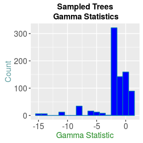

```r
ggplot2::ggplot(
  data = df_species_trees, ggplot2::aes(df_species_trees$gamma_stat)) +
  ggplot2::geom_histogram(binwidth = 1,
                          colour = "#0072B2", fill = "blue") +
  ggplot2::theme(text = ggplot2::element_text(size = 12)) +
  ggplot2::theme(axis.text = ggplot2::element_text(size = 12)) +
  ggplot2::xlab("Gamma Statistic") +
  ggplot2::theme(axis.title.x = ggplot2::element_text(color="forestgreen",
                                             vjust=-0.35)) +
  ggplot2::ylab("Count") +
  ggplot2::theme(axis.title.y = ggplot2::element_text(color="cadetblue" ,
                                             vjust=0.35)) +
  ggplot2::ggtitle("Sampled Trees\n Gamma Statistics") +
  ggplot2::theme(plot.title = ggplot2::element_text(size=12,
                                  face="bold",
                                  vjust=1,
                                  lineheight=1))
```

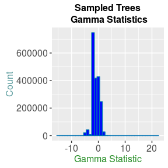

```r
ggplot2::ggplot(
  data = df_posterior, ggplot2::aes(df_posterior$gamma_stat)) +
  ggplot2::geom_histogram(binwidth = 1,
                          colour = "#0072B2", fill = "blue") +
  ggplot2::theme(text = ggplot2::element_text(size = 12)) +
  ggplot2::theme(axis.text = ggplot2::element_text(size = 12)) +
  ggplot2::xlab("Gamma Statistic") +
  ggplot2::theme(axis.title.x = ggplot2::element_text(color="forestgreen",
                                             vjust=-0.35)) +
  ggplot2::ylab("Count") +
  ggplot2::theme(axis.title.y = ggplot2::element_text(color="cadetblue" ,
                                             vjust=0.35)) +
  ggplot2::ggtitle("Sampled Trees\n Gamma Statistics") +
  ggplot2::theme(plot.title = ggplot2::element_text(size=12,
                                  face="bold",
                                  vjust=1,
                                  lineheight=1))
```

Hey, some of those gamma statistics are quite different between the species trees and the posterior! Let’s take a look at that.

```r
counter <- 0
interesting_values <- NULL
for (stat in df_species_trees$gamma_stat){
  counter <- counter + 1
  if ( !is.na(stat) && (stat < -10)){
    interesting_values$filenames  <- c(interesting_values$filenames,
                                       df_species_trees$filenames[counter])
    interesting_values$gamma_stat <- c(interesting_values$gamma_stat, stat)
    interesting_values$treenumber <- c(interesting_values$treenumber,
                                       df_species_trees$species_tree[counter])
  }
}
interesting_values <- data.frame(interesting_values)
```

```r
knitr::kable(interesting_values)
```

| filenames | gamma_stat | treenumber |
| --- | --- | --- |
| article_1_0_0_0_1.RDa | -14.48119 | 1 |
| article_1_0_0_0_1.RDa | -14.53100 | 2 |
| article_1_0_0_0_2.RDa | -14.48119 | 1 |
| article_1_0_0_0_2.RDa | -14.53100 | 2 |
| article_1_0_0_1_1.RDa | -14.48119 | 1 |
| article_1_0_0_1_1.RDa | -14.53100 | 2 |
| article_1_0_0_1_2.RDa | -14.48119 | 1 |
| article_1_0_0_1_2.RDa | -14.53100 | 2 |
| article_1_0_0_2_1.RDa | -14.48119 | 1 |
| article_1_0_0_2_1.RDa | -14.53100 | 2 |
| article_1_0_0_2_2.RDa | -14.48119 | 1 |
| article_1_0_0_2_2.RDa | -14.53100 | 2 |
| article_1_1_0_0_1.RDa | -11.34168 | 1 |
| article_1_1_0_0_1.RDa | -11.28420 | 2 |
| article_1_1_0_0_2.RDa | -11.34168 | 1 |
| article_1_1_0_0_2.RDa | -11.28420 | 2 |
| article_1_1_0_1_1.RDa | -11.34168 | 1 |
| article_1_1_0_1_1.RDa | -11.28420 | 2 |
| article_1_1_0_1_2.RDa | -11.34168 | 1 |
| article_1_1_0_1_2.RDa | -11.28420 | 2 |
| article_1_1_0_2_1.RDa | -11.34168 | 1 |
| article_1_1_0_2_1.RDa | -11.28420 | 2 |
| article_1_1_0_2_2.RDa | -11.34168 | 1 |
| article_1_1_0_2_2.RDa | -11.28420 | 2 |

It seems like there are clusters of files that have very low gamma statistics. Let’s compare them to the posterior values for those statistics.

```r
counter    <- 0
outliers   <- NULL
for (posterior in df_posterior$filenames){
  counter  <- counter + 1
  counter2 <- 0
  for (filename in interesting_values$filenames){
    counter2 <- counter2 + 1
    if (posterior == filename){
      outliers$filenames  <- c(outliers$filenames,
                               df_posterior$filenames[counter])
      outliers$gamma_post <- c(outliers$gamma_post,
                               df_posterior$gamma_stat[counter])
      outliers$gamma_int  <- c(outliers$gamma_int,
                               interesting_values$gamma_stat[counter2])
      outliers$treenumber <- c(outliers$treenumber,
                               interesting_values$treenumber[counter2])
    }
  }
}

outliers <- data.frame(outliers)

print(names(outliers))
```

```
## [1] "filenames"  "gamma_post" "gamma_int"  "treenumber"
```

```r
knitr::kable(outliers)
```

| filenames | gamma_post | gamma_int | treenumber |
| --- | --- | --- | --- |
| article_1_0_0_0_1.RDa | NA | -14.48119 | 1 |
| article_1_0_0_0_1.RDa | NA | -14.53100 | 2 |
| article_1_0_0_0_2.RDa | NA | -14.48119 | 1 |
| article_1_0_0_0_2.RDa | NA | -14.53100 | 2 |
| article_1_0_0_1_1.RDa | NA | -14.48119 | 1 |
| article_1_0_0_1_1.RDa | NA | -14.53100 | 2 |
| article_1_0_0_1_2.RDa | NA | -14.48119 | 1 |
| article_1_0_0_1_2.RDa | NA | -14.53100 | 2 |
| article_1_0_0_2_1.RDa | NA | -14.48119 | 1 |
| article_1_0_0_2_1.RDa | NA | -14.53100 | 2 |
| article_1_0_0_2_2.RDa | NA | -14.48119 | 1 |
| article_1_0_0_2_2.RDa | NA | -14.53100 | 2 |
| article_1_1_0_0_1.RDa | NA | -11.34168 | 1 |
| article_1_1_0_0_1.RDa | NA | -11.28420 | 2 |
| article_1_1_0_0_2.RDa | NA | -11.34168 | 1 |
| article_1_1_0_0_2.RDa | NA | -11.28420 | 2 |
| article_1_1_0_1_1.RDa | NA | -11.34168 | 1 |
| article_1_1_0_1_1.RDa | NA | -11.28420 | 2 |
| article_1_1_0_1_2.RDa | NA | -11.34168 | 1 |
| article_1_1_0_1_2.RDa | NA | -11.28420 | 2 |
| article_1_1_0_2_1.RDa | NA | -11.34168 | 1 |
| article_1_1_0_2_1.RDa | NA | -11.28420 | 2 |
| article_1_1_0_2_2.RDa | NA | -11.34168 | 1 |
| article_1_1_0_2_2.RDa | NA | -11.28420 | 2 |

All the low outliers don’t seem to have a posterior… so the difference in the graphs might not actually mean anything. Let’s take a different approach. Let’s compare the gamma statistics of every tree that has a posterior.

```r
comparison  <- NULL
for (stat in head(df_posterior$gamma_stat)){
  counter <- 0
  if (!is.na(stat)){
    for (value in head(df_species_trees$gamma_stat)){
      counter <- counter + 1
      if (!is.na(value)){
        comparison$filenames  <- c(comparison$filenames,
                                   df_species_trees$filenames[counter])
        comparison$treenumber <- c(comparison$treenumber,
                                   df_species_trees$species_tree[counter])
        comparison$gamma_pbd  <- c(comparison$gamma_pbd, value)
        comparison$gamma_post <- c(comparison$gamma_post, stat)
        comparison$diff       <- c(comparison$diff,
                                   (value - stat))
      }
    }
  }
}
comparison <- data.frame(comparison)
```

```r
knitr::kable(comparison)
```

| filenames | treenumber | gamma_pbd | gamma_post | diff |
| --- | --- | --- | --- | --- |
| article_0_0_0_0_2.RDa | 1 | 0.1567163 | 0.1962860 | -0.0395698 |
| article_0_0_0_0_2.RDa | 2 | 0.1567163 | 0.1962860 | -0.0395698 |
| article_0_0_0_0_2.RDa | 1 | 0.1567163 | 0.1709388 | -0.0142225 |
| article_0_0_0_0_2.RDa | 2 | 0.1567163 | 0.1709388 | -0.0142225 |
| article_0_0_0_0_2.RDa | 1 | 0.1567163 | 0.2194888 | -0.0627725 |
| article_0_0_0_0_2.RDa | 2 | 0.1567163 | 0.2194888 | -0.0627725 |
| article_0_0_0_0_2.RDa | 1 | 0.1567163 | 0.1643772 | -0.0076610 |
| article_0_0_0_0_2.RDa | 2 | 0.1567163 | 0.1643772 | -0.0076610 |

## Richel’s thoughts

I would be interested in the species trees with a gamma statistic less than `-5`:

```r
species_trees_with_low_gamma <- df_species_trees[
  !is.na(df_species_trees$gamma_stat) & df_species_trees$gamma_stat < -5,
]
knitr::kable(head(species_trees_with_low_gamma))
```

|  | filenames | species_tree | gamma_stat |
| --- | --- | --- | --- |
| 364 | article_1_0_0_0_1.RDa | 1 | -14.48119 |
| 365 | article_1_0_0_0_1.RDa | 2 | -14.53100 |
| 366 | article_1_0_0_0_2.RDa | 1 | -14.48119 |
| 367 | article_1_0_0_0_2.RDa | 2 | -14.53100 |
| 369 | article_1_0_0_1_1.RDa | 1 | -14.48119 |
| 370 | article_1_0_0_1_1.RDa | 2 | -14.53100 |

Which parameters go with that?

First read all parameters:

```r
csv_filename_parameters <- "collected_parameters.csv"
testit::assert(file.exists(csv_filename_parameters))
df_parameters <- read.csv(
 file = csv_filename_parameters,
 header = TRUE,
 stringsAsFactors = FALSE,
 row.names = 1
)
knitr::kable(head(df_parameters))
```

|  | rng_seed | species_initiation_rate_good_species | species_initiation_rate_incipient_species | speciation_completion_rate | extinction_rate_good_species | extinction_rate_incipient_species | age | n_species_trees_samples | mutation_rate | n_alignments | sequence_length | mcmc_chainlength | n_beast_runs | version |
| --- | --- | --- | --- | --- | --- | --- | --- | --- | --- | --- | --- | --- | --- | --- |
| article_0_0_0_0_0.RDa | NA | NA | NA | NA | NA | NA | NA | NA | NA | NA | NA | NA | NA | NA |
| article_0_0_0_0_1.RDa | NA | NA | NA | NA | NA | NA | NA | NA | NA | NA | NA | NA | NA | NA |
| article_0_0_0_0_2.RDa | 1 | 0.1 | 0.1 | 0.1 | 0 | 0 | 15 | 2 | 0.1 | 2 | 100000 | 1000000 | 2 | 0.1 |
| article_0_0_0_1_0.RDa | NA | NA | NA | NA | NA | NA | NA | NA | NA | NA | NA | NA | NA | NA |
| article_0_0_0_1_1.RDa | NA | NA | NA | NA | NA | NA | NA | NA | NA | NA | NA | NA | NA | NA |
| article_0_0_0_1_2.RDa | NA | NA | NA | NA | NA | NA | NA | NA | NA | NA | NA | NA | NA | NA |

Show the parameters that caused this:

```r
parameters_with_low_gamma <- df_parameters[
  rownames(df_parameters) %in% species_trees_with_low_gamma$filename,
]
knitr::kable(head(parameters_with_low_gamma))
```

|  | rng_seed | species_initiation_rate_good_species | species_initiation_rate_incipient_species | speciation_completion_rate | extinction_rate_good_species | extinction_rate_incipient_species | age | n_species_trees_samples | mutation_rate | n_alignments | sequence_length | mcmc_chainlength | n_beast_runs | version |
| --- | --- | --- | --- | --- | --- | --- | --- | --- | --- | --- | --- | --- | --- | --- |
| article_1_0_0_0_1.RDa | 1 | 0.5 | 0.5 | 0.1 | 0 | 0 | 15 | 2 | 0.100 | 2 | 10000 | 1000000 | 2 | 0.1 |
| article_1_0_0_0_2.RDa | 1 | 0.5 | 0.5 | 0.1 | 0 | 0 | 15 | 2 | 0.100 | 2 | 100000 | 1000000 | 2 | 0.1 |
| article_1_0_0_1_1.RDa | 1 | 0.5 | 0.5 | 0.1 | 0 | 0 | 15 | 2 | 0.010 | 2 | 10000 | 1000000 | 2 | 0.1 |
| article_1_0_0_1_2.RDa | 1 | 0.5 | 0.5 | 0.1 | 0 | 0 | 15 | 2 | 0.010 | 2 | 100000 | 1000000 | 2 | 0.1 |
| article_1_0_0_2_1.RDa | 1 | 0.5 | 0.5 | 0.1 | 0 | 0 | 15 | 2 | 0.001 | 2 | 10000 | 1000000 | 2 | 0.1 |
| article_1_0_0_2_2.RDa | 1 | 0.5 | 0.5 | 0.1 | 0 | 0 | 15 | 2 | 0.001 | 2 | 100000 | 1000000 | 2 | 0.1 |

Let’s look at what parameters are often there in the corrupted files.

```r
na_sample    <- NULL
counter      <- 0
for (stat in df_species_trees$gamma_stat){
  counter <- counter + 1
  if (!is.na(stat)){
    counter2 <- 0
    for (filename in row.names(df_parameters)){
      counter2 <- counter2 + 1
      if (filename == df_species_trees$filenames[counter]){
        na_sample$filenames   <- c(na_sample$filenames,
                                   df_species_trees$filenames[counter])
        na_sample$treenumber  <- c(na_sample$treenumber,
                                   df_species_trees$species_tree[counter])
        na_sample$gamma_stat  <- c(na_sample$gamma_stat, stat)
        na_sample$SIR_GS      <- c(na_sample$SIR_GS,
                   df_parameters$species_initiation_rate_good_species[counter2])
        na_sample$SIR_IS      <- c(na_sample$SIR_IS,
              df_parameters$species_initiation_rate_incipient_species[counter2])
        na_sample$SCR         <- c(na_sample$SCR,
                             df_parameters$speciation_completion_rate[counter2])
        na_sample$EXT_GS      <- c(na_sample$EXT_GS,
                           df_parameters$extinction_rate_good_species[counter2])
        na_sample$EXT_IS      <- c(na_sample$EXT_IS,
                      df_parameters$extinction_rate_incipient_species[counter2])
        na_sample$AGE         <- c(na_sample$AGE, df_parameters$age[counter2])
        na_sample$MUTATIONR   <- c(na_sample$MUTATIONR,
                                   df_parameters$mutation_rate[counter2])
        break
      }
    }
  }
}
na_sample <- data.frame(na_sample)
```

```r
knitr::kable(head(na_sample))
```

| filenames | treenumber | gamma_stat | SIR_GS | SIR_IS | SCR | EXT_GS | EXT_IS | AGE | MUTATIONR |
| --- | --- | --- | --- | --- | --- | --- | --- | --- | --- |
| article_0_0_0_0_2.RDa | 1 | 0.1567163 | 0.1 | 0.1 | 0.1 | 0.0 | 0.0 | 15 | 0.100 |
| article_0_0_0_0_2.RDa | 2 | 0.1567163 | 0.1 | 0.1 | 0.1 | 0.0 | 0.0 | 15 | 0.100 |
| article_0_0_2_2_2.RDa | 1 | -1.7320508 | 0.1 | 0.1 | 0.1 | 0.2 | 0.2 | 15 | 0.001 |
| article_0_0_2_2_2.RDa | 2 | -1.7320508 | 0.1 | 0.1 | 0.1 | 0.2 | 0.2 | 15 | 0.001 |
| article_0_0_3_0_2.RDa | 1 | -1.7320508 | 0.1 | 0.1 | 0.1 | 0.4 | 0.4 | 15 | 0.100 |
| article_0_0_3_0_2.RDa | 2 | -1.7320508 | 0.1 | 0.1 | 0.1 | 0.4 | 0.4 | 15 | 0.100 |

It seems like there is one parameter which is unusually often present in corrupt files: a species initiation rate of 0.4. For some reason, these are very often corrupted. This is very unexpected, as we’d expect something going wrong with the program if the computer would be overwhelmed by calculations - for example if the speciation initiatoin rate is high. But high speciation rates seem to be fine:

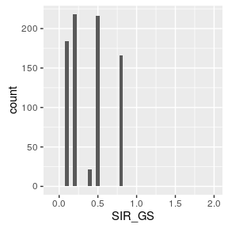

```r
ggplot2::qplot(SIR_GS, data = na_sample, binwidth = 0.05, xlim = c(-0.1, 2))
```

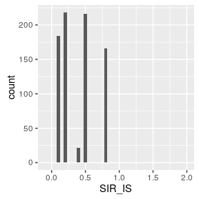

```r
ggplot2::qplot(SIR_IS, data = na_sample, binwidth = 0.05, xlim = c(-0.1, 2))
```